# Observational Studies and Experiments

November 7, 2017

## Heart Attack Survival

A [2008 article](http://articles.latimes.com/2008/jan/03/science/sci-heart3) in the Los Angeles Times begins:

*"People who suffer cardiac arrest are more likely to survive if they are in a casino or airport than if they are in a hospital, researchers said today."*

The article was based on a study that found:

1. More than half of people who suffer a heart attack in a casino or airport survive
2. Only one third of hospital patients who suffer a heart attack survive

## Effect of Defibrillation

The explanatory variable we are interested in is location and the response variable is survival.

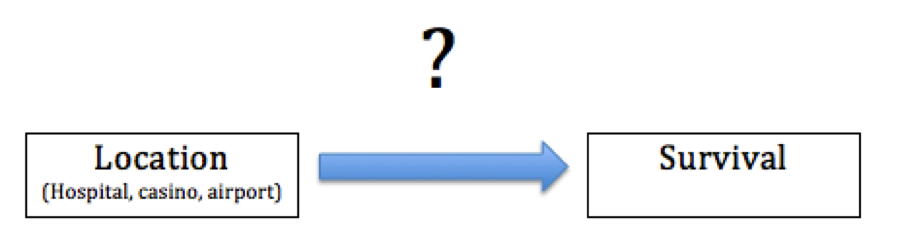

The article hypothesizes that the difference in survival rates can be explained by availability of defibrillators…

However, the article states that only 40% of hospital patients who receive defibrillation within 2 minutes survived.

This is still lower than the survival rate at casinos and airports!

## Another Explanation

*"At least part of the apparent discrepancy arises because hospital patients are sicker to begin with, whereas those who suffer attacks in airports and casinos generally don't have underlying illnesses or symptoms, said UCLA cardiologist Gregg C. Fonarow, who was not involved in the study."*

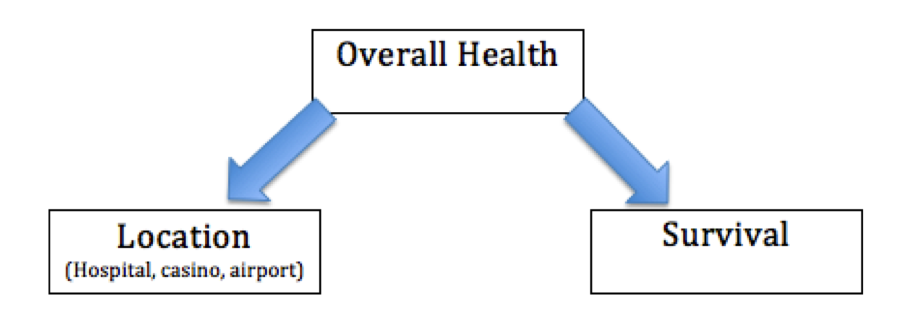

## Confounding

A **confounding** variable is a third variable that is associated with both the explanatory variable and the response variable.

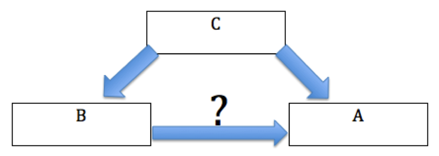

A confounding variable can offer a plausible explanation for an association between two variables of interest.

## Horticulture Example

A horticultural researcher is interested in studying the relationship between the amount of fertilizer applied and crop yield in blueberries.

The researcher visits three farms and records the amount of fertilizer used (in lb N/acre) and the yield (lb/acre).

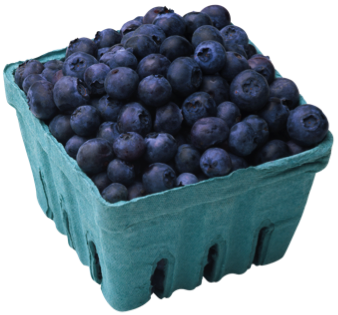

## Horticulture Example (cont.)

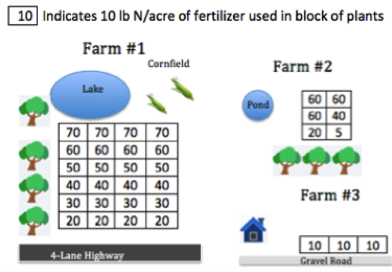

Suppose the researcher finds that yield increases as amount of fertilizer increases. Why shouldn't the researcher conclude that using more fertilizer causes better yield in blueberries?

## A Better Strategy

In order to account for differences in soil composition, sunlight, irrigation, etc., the researcher should randomly determine how much fertilizer each block of land will receive and apply each fertilizer under the same conditions.

1. Divide fields into plots of land.
2. Randomly assign fertilizer amounts to plots.
3. Fertilize plots under identical conditions (same day, equipment, etc.)
4. Record yields and analyze differences.

## Definitions

An **experiment** is a study in which the researcher actively controls one or more of the explanatory variables.

An **observational** study is a study in which the researcher does not actively control the value of any variable but simply observes the values as they naturally exist.

In a **randomized experiment** the value of the explanatory variable for each unit is determined randomly, before the response variable is measured.

In a randomized experiment, we can infer that differences in the response variable are *caused* by the explanatory variable.

Definitions from Lock et al. (2013)

## Example 1

Experiment or Observational Study?

A researcher records the number of hours of violent television programming watched per week, for a group of 1000 teenagers. The researcher also observes the number of violent crimes committed by each teenager in the last two years.

## Example 2

Experiment or Observational Study?

College students were randomly divided into two groups. Students in the first group played a violent video game, while students in the second group played a nonviolent videogame. After the game, players were given the opportunity to "blast" opponents with an unpleasant noise of an intensity and duration chosen by the player. A researcher records the intensities and durations selected by students who played each type of video game.

## Example 3

Experiment or Observational Study?

Example: A 1999 study by Quinn, Shin, Maguire, and Stone examined the relationship between myopia (near-sightnedness) and exposure to light before the age of two. Parents of 479 children (age 2-16) at a pediatric clinic were asked:

"Under which lighting condition does/did your child sleep at night" before the age of 2 years?

Room lighting / A night light / darkeness

## Night Lighting and Mypoia

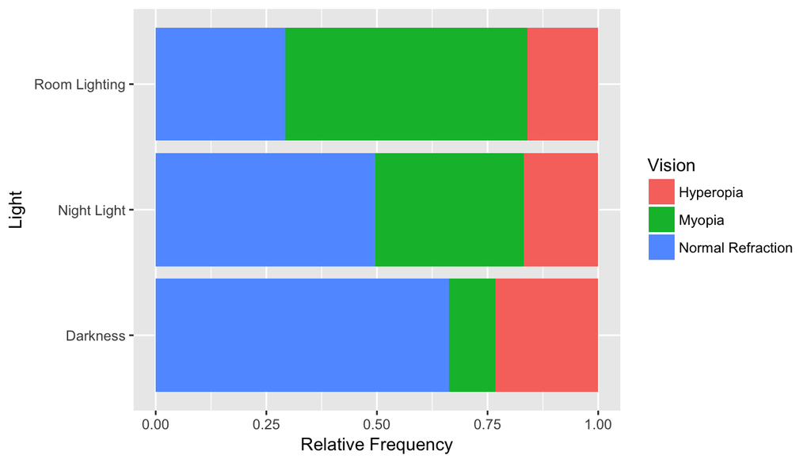

## Light at Night Study Conclusions

*"Although it does not establish a causal link, the statistical strength of the association of night-time light exposure and childhood myopia does suggest that the absence of a daily period of darkness during early childhood is a potential precipitating factor in the development of myopia….it seems prudent that infants and young children sleep at night without artificial lighting in the bedroom, while the present findings are evaluated more comprehensively.*

Identify a confounding variable that might be relevent in this study.

How might researchers design an experiment to assess the effect of ambient light on developing mypoia?

## Further Research on Mypoia

Subsequent work by Zadnik et al. and Gwaizda et al. found no relationship between amount of light at night and risk of myopia. Instead, they found that myopic parents left the light on at night more often than non-myopic parents.

Since children of mypoic parents are more likely to develop myopia, genetics are a confounding factor in this study.

## Summary

- Confounding occurs when a third variable is associated with both variables we are interested in
- Observation studies involve merely observing units of interest
  - Cannot infer causal relationship due to possibility of confounding
- Experiments involve actively administering a treatment
  - Can infer causal relationship if well designed
- Experiments are usually preferred when possible
- Experiments must be designed carefully